# GWAS Catalog store curation

Delineating full-summary-statistic analyses into candidate OpenGWASDB stores

Published

July 14, 2026

```r
library(data.table)
library(ggplot2)

derived_dir <- "../data/derived"
summary_path <- file.path(derived_dir, "store-candidates-summary.tsv")
analyses_path <- file.path(derived_dir, "store-candidates-analyses.tsv")

# The curation itself lives in ebi-studies.r and writes the two TSVs below.
# Parsing the free-text sample-size field over the whole catalogue takes ~1
# minute, so this report reads the pre-computed outputs rather than re-running
# the pipeline. Regenerate them with:  Rscript resources/scripts/ebi-studies.r
if (!file.exists(summary_path) || !file.exists(analyses_path)) {
  stop("Derived tables not found. Run `Rscript resources/scripts/ebi-studies.r` first.")
}

store_summary <- fread(summary_path, sep = "\t", na.strings = "")
analyses <- fread(analyses_path, sep = "\t", na.strings = "")

fmt_int <- function(x) formatC(x, format = "d", big.mark = ",")
```

## What this is

Every row of the GWAS Catalog studies file is one **Analysis** (one trait tested against variants). This report groups the analyses that ship **full summary statistics** into candidate stores of three kinds:

- **dense** — one publication, one ancestry, ≥100 mostly complex/clinical-trait analyses from a shared cohort;
- **ragged** — one publication, one ancestry, ≥100 mostly molecular-trait analyses (proteomics, metabolomics, …);
- **hybrid** — everything left over, pooled by major ancestry group across many publications.

```r
n_full <- nrow(analyses)
by_type <- store_summary[, .(
  stores = .N,
  analyses = sum(n_analyses)
), by = store_type][order(-analyses)]

knitr::kable(
  rbind(by_type, data.table(store_type = "TOTAL",
                            stores = sum(by_type$stores),
                            analyses = sum(by_type$analyses))),
  col.names = c("Store type", "Candidate stores", "Analyses"),
  format.args = list(big.mark = ","),
  caption = sprintf("%s analyses with full summary statistics across %s candidate stores.",
                    fmt_int(n_full), fmt_int(nrow(store_summary)))
)
```

171,274 analyses with full summary statistics across 135 candidate stores.

| Store type | Candidate stores | Analyses |
| --- | --- | --- |
| ragged | 56 | 103,651 |
| dense | 67 | 59,002 |
| hybrid | 12 | 8,621 |
| TOTAL | 135 | 171,274 |

## Store size distribution

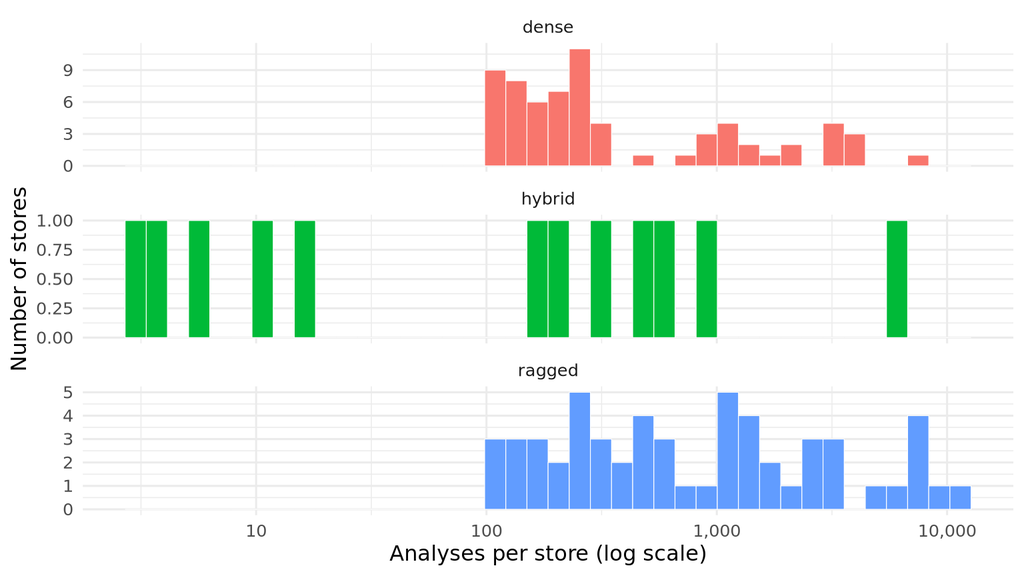

```r
ggplot(store_summary, aes(x = n_analyses, fill = store_type)) +
  geom_histogram(bins = 40, colour = "white", linewidth = 0.2) +
  scale_x_log10(labels = scales::comma) +
  facet_wrap(~store_type, scales = "free_y", ncol = 1) +
  labs(x = "Analyses per store (log scale)", y = "Number of stores",
       fill = "Store type") +
  theme_minimal(base_size = 12) +
  theme(legend.position = "none")
```

## Ragged stores by molecular type

Each ragged store is a single-publication molecular-QTL dataset. `molecular_type` is taken from the study title (a store is one omics platform), falling back to the dominant per-analysis trait subtype for method-titled papers.

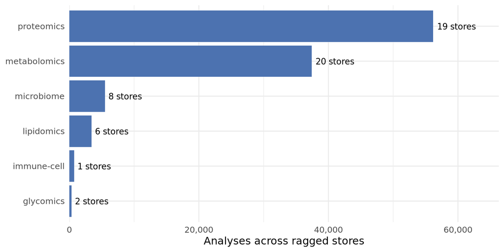

```r
rag <- store_summary[store_type == "ragged"]
rag[, molecular_type := fifelse(is.na(molecular_type), "unresolved", molecular_type)]

type_counts <- rag[, .(stores = .N, analyses = sum(n_analyses)), by = molecular_type][order(-analyses)]

ggplot(type_counts, aes(x = reorder(molecular_type, analyses), y = analyses)) +
  geom_col(fill = "#4c72b0") +
  geom_text(aes(label = sprintf("%s stores", stores)), hjust = -0.1, size = 3.4) +
  scale_y_continuous(labels = scales::comma, expand = expansion(mult = c(0, 0.18))) +
  coord_flip() +
  labs(x = NULL, y = "Analyses across ragged stores") +
  theme_minimal(base_size = 12)
```

```r
DT::datatable(
  rag[order(molecular_type, -n_analyses),
      .(store_key, molecular_type, ancestry = ancestry_group, n = n_analyses,
        median_variants, median_N = median_sample_size,
        est_gb = est_completed_size_gb, hit_prop = prop_with_gwas_hit,
        review = fifelse(is.na(review_reason), "", review_reason))],
  rownames = FALSE, filter = "top",
  options = list(pageLength = 15, scrollX = TRUE),
  caption = "Ragged stores labelled by molecular type.")
```

| store_key | molecular_type | ancestry | n | median_variants | median_N | est_gb | hit_prop | review |
| --- | --- | --- | --- | --- | --- | --- | --- | --- |
| ragged__pmid-40593539__European | glycomics | European | 234 | 5394690 | 8856 | 0 | 0.141 |  |
| ragged__pmid-40593539__Multiple-Mixed | glycomics | Multiple/Mixed | 117 | 5394690 | 3224 | 0 | 0 |  |
| ragged__pmid-32929287__European | immune-cell | European | 731 | 18236953 | 3427 | 0.4 | 0.84 | ambiguous molecular fraction; title vs trait-text disagreement; |
| ragged__pmid-35668104__European | lipidomics | European | 1868 | 13869437 | 4492 | 0.9 | 0.551 | title vs trait-text disagreement; |
| ragged__pmid-34503513__European | lipidomics | European | 477 | 87696910 | 13814 | 1.4 | 0.512 | title vs trait-text disagreement; |
| ragged__pmid-34503513__South-Asian | lipidomics | South Asian | 445 | 6720657 | 5662 | 0.1 | 0.407 | title vs trait-text disagreement; |
| ragged__pmid-35213538__European | lipidomics | European | 249 | 11722792 | 115082 | 0.1 | 1 | ambiguous molecular fraction; title vs trait-text disagreement; |
| ragged__pmid-39753034__European | lipidomics | European | 227 | 7163154 | 1149 | 0.1 | 0.229 | title vs trait-text disagreement; |
| ragged__pmid-37907536__European | lipidomics | European | 179 | 11318730 | 7076 | 0.1 | 0.905 | title vs trait-text disagreement; |
| ragged__pmid-40789849__European | metabolomics | European | 8390 | 10448203 | 2338 | 2.9 | 0.334 |  |

[output cut: 46 more lines]

## Single-publication stores (dense & ragged)

Representative variant counts (`median_variants`) and sample sizes come from the `PLATFORM [SNPS PASSING QC]` and `INITIAL SAMPLE SIZE` fields. `n_case_control` / `n_quantitative` split the analyses by study design. Dense stores are general complex/clinical-trait batches (`molecular_type` empty); a dense store that does carry a molecular type is flagged for review as a possible mis-split.

`est_gb` estimates the reference-completed store size. **Dense/hybrid** stores are a full trait × reference-variant matrix: reference completion projects every analysis onto the same 12M-variant panel, so size is n_analyses × 12M × 2.5 bytes/cell (calibrated on ukb-b) — a study imputed to a denser panel still completes to the reference. **Ragged** stores are sparse: each molecular-QTL analysis keeps only ~20 Mb of the genome (cis + trans + suggestive) at ~5 bytes per stored variant, i.e. n_variants × 20/3000 × 5 bytes, so they are far smaller than a dense matrix of the same analysis count.

`hit_prop` is the proportion of analyses with ≥1 genome-wide-significant association (from `ASSOCIATION COUNT`). A low value across a store’s analyses is an objective signal that the study was underpowered overall.

```r
sp <- store_summary[store_type != "hybrid"][order(-est_completed_size_gb)]
DT::datatable(
  sp[, .(store_key, type = store_type,
         molecular_type = fifelse(is.na(molecular_type), "", molecular_type),
         n = n_analyses, cc = n_case_control, quant = n_quantitative,
         med_variants = median_variants, med_N = median_sample_size,
         est_gb = est_completed_size_gb, hit_prop = prop_with_gwas_hit,
         review = fifelse(is.na(review_reason), "", review_reason))],
  rownames = FALSE, filter = "top",
  options = list(pageLength = 15, scrollX = TRUE),
  caption = sprintf("All %d single-publication stores (sorted by estimated size).", nrow(sp)))
```

| store_key | type | molecular_type | n | cc | quant | med_variants | med_N | est_gb | hit_prop | review |
| --- | --- | --- | --- | --- | --- | --- | --- | --- | --- | --- |
| dense__pmid-34662886__European | dense |  | 7972 | 7390 | 582 | 185344 | 370391 | 239.2 | 0.025 |  |
| dense__pmid-41606330__East-Asian | dense | lipidomics | 4092 | 99 | 3993 | 1009482 | 41473 | 122.8 | 0.012 | dense store looks molecular (lipidomics); |
| dense__pmid-41606330__European | dense | lipidomics | 4092 | 99 | 3993 | 1478389 | 152500 | 122.8 | 0.002 | dense store looks molecular (lipidomics); |
| dense__pmid-33875891__European | dense |  | 3935 | 0 | 3935 | 17103079 | 21081 | 118 | 0.286 |  |
| dense__pmid-38811844__East-Asian | dense |  | 3414 | 0 | 3414 | 7011794 | 7058 | 102.4 | 0.17 |  |
| dense__pmid-38811844__European | dense |  | 3414 | 0 | 3414 | 6116557 | 40282 | 102.4 | 0 |  |
| dense__pmid-39024449__European | dense |  | 3360 | 2959 | 401 | 44300000 | 447280 | 100.8 | 0.601 | mixed-ancestry cohort; |
| dense__pmid-34737426__European | dense |  | 2989 | 2986 | 3 | 11842647 | 455272 | 89.7 | 0.025 |  |
| dense__pmid-39271676__European | dense |  | 2212 | 0 | 2212 | 12687368 | 15127 | 66.4 | 0 |  |
| dense__pmid-41044249__European | dense |  | 1992 | 0 | 1992 | 8392241 | 434646 | 59.8 | 0.365 |  |

[output cut: 113 more lines]

```r
knitr::kable(
  store_summary[, .(stores = .N,
                    analyses = sum(n_analyses),
                    est_total_gb = round(sum(est_completed_size_gb))),
                by = store_type][order(-est_total_gb)],
  col.names = c("Store type", "Stores", "Analyses", "Est. completed size (GB)"),
  format.args = list(big.mark = ","),
  caption = "Estimated total storage after reference completion, by store type.")
```

Estimated total storage after reference completion, by store type.

| Store type | Stores | Analyses | Est. completed size (GB) |
| --- | --- | --- | --- |
| dense | 67 | 59,002 | 1,770 |
| hybrid | 12 | 8,621 | 258 |
| ragged | 56 | 103,651 | 33 |

### Variant count vs sample size

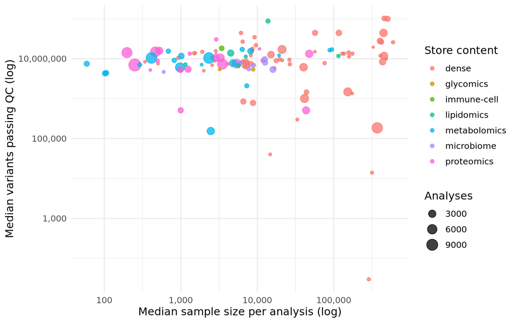

```r
sp_pts <- copy(sp)
sp_pts[, fill_type := fifelse(store_type == "dense", "dense",
                       fifelse(is.na(molecular_type), "ragged (other)", molecular_type))]
ggplot(sp_pts[!is.na(median_variants) & !is.na(median_sample_size)],
       aes(x = median_sample_size, y = median_variants, colour = fill_type,
           size = n_analyses)) +
  geom_point(alpha = 0.75) +
  scale_x_log10(labels = scales::comma) +
  scale_y_log10(labels = scales::comma) +
  labs(x = "Median sample size per analysis (log)",
       y = "Median variants passing QC (log)",
       colour = "Store content", size = "Analyses") +
  theme_minimal(base_size = 12)
```

## Hybrid stores by ancestry

Left-over analyses pooled across publications, one store per major ancestry group. Variant and sample-size medians here span many publications, so they are indicative only.

```r
hy <- store_summary[store_type == "hybrid"][order(-n_analyses)]
knitr::kable(
  hy[, .(ancestry_group, n_analyses, n_pubmed_ids,
         median_variants, median_sample_size)],
  col.names = c("Ancestry group", "Analyses", "Publications",
                "Median variants", "Median N"),
  format.args = list(big.mark = ","))
```

| Ancestry group | Analyses | Publications | Median variants | Median N |
| --- | --- | --- | --- | --- |
| European | 6,035 | 1,007 | 8,642,454 | 38,816 |
| East Asian | 852 | 139 | 8,315,681 | 4,526 |
| African | 550 | 96 | 14,441,866 | 6,393 |
| Multiple/Mixed | 450 | 74 | 7,614,734 | 36,083 |
| Hispanic or Latin American | 347 | 46 | 21,894,105 | 11,584 |
| NR/Unknown | 198 | 25 | 5,520,002 | 6,006 |
| South Asian | 150 | 27 | 5,000,000 | 8,188 |
| Asian (unspecified) | 15 | 5 | 12,553,142 | 4,672 |
| Greater Middle Eastern | 11 | 4 | 8,488,404 | 5,885 |
| Native American | 6 | 2 | 1,638,140 | 358 |
| Other | 4 | 3 | 18,086,209 | 2,202 |
| South East Asian | 3 | 2 | 47,095,002 | 1,721 |

## Analyses flagged for review

```r
rv <- store_summary[needs_review == TRUE,
                    .(store_key, store_type, n_analyses, review_reason)][order(store_type, -n_analyses)]
cat(sprintf("%d of %d candidate stores flagged for manual review.\n\n",
            nrow(rv), nrow(store_summary)))
```

```
48 of 135 candidate stores flagged for manual review.
```

```r
DT::datatable(rv, rownames = FALSE, filter = "top",
  colnames = c("Store", "Type", "Analyses", "Review reason"),
  options = list(pageLength = 10, scrollX = TRUE))
```

| Store | Type | Analyses | Review reason |
| --- | --- | --- | --- |
| dense__pmid-41606330__East-Asian | dense | 4092 | dense store looks molecular (lipidomics); |
| dense__pmid-41606330__European | dense | 4092 | dense store looks molecular (lipidomics); |
| dense__pmid-39024449__European | dense | 3360 | mixed-ancestry cohort; |
| dense__pmid-42069741__European | dense | 1826 | dense store looks molecular (lipidomics); |
| dense__pmid-36088354__European | dense | 300 | ambiguous molecular fraction; |
| dense__pmid-38448586__European | dense | 233 | ambiguous molecular fraction; mixed-ancestry cohort; dense store looks molecular (metabolomics); |
| dense__pmid-34594039__East-Asian | dense | 231 | mixed-ancestry cohort; |
| dense__pmid-34594039__European | dense | 209 | mixed-ancestry cohort; |
| dense__pmid-42203880__European | dense | 142 | mixed-ancestry cohort; |
| dense__pmid-33414548__European | dense | 141 | dense store looks molecular (lipidomics); |

[output cut: 38 more lines]

## Per-analysis sample sizes

Each analysis carries its own design and counts: case/control counts for binary traits, total sample size for quantitative traits.

```r
knitr::kable(
  analyses[, .(design = fifelse(is.na(study_design), "unknown", study_design),
               analyses = .N,
               median_N = as.integer(median(sample_size, na.rm = TRUE))),
           by = study_design][, .(design, analyses, median_N)][order(-analyses)],
  col.names = c("Study design", "Analyses", "Median sample size"),
  format.args = list(big.mark = ","))
```

| Study design | Analyses | Median sample size |
| --- | --- | --- |
| quantitative | 148,303 | 3,283 |
| case-control | 22,971 | 360,138 |

## EUR hybrid prioritisation

The European hybrid store pools many single-trait analyses from different publications, so the same trait is often measured several times. To decide what to include in a reference-completed array, analyses are clustered by EFO term and ranked within each cluster on power (sample size / n_cases), SNP density, and curated hits (down-weighted). The top few per trait are kept; the rest are flagged as redundant. Produced by `eur-hybrid-prioritise.r`.

```r
prio_path <- file.path(derived_dir, "eur-hybrid-prioritisation.tsv")
if (file.exists(prio_path)) {
  prio <- fread(prio_path, sep = "\t", na.strings = "")
  n_keep <- sum(prio$recommendation == "keep")
  n_drop <- sum(prio$recommendation == "redundant")
  gb_drop <- sum(prio[recommendation == "redundant", est_analysis_gb])
  gb_all <- sum(prio$est_analysis_gb)
  cat(sprintf("%s analyses in %s EFO clusters. Keeping the best %d per trait drops %s redundant analyses (%.0f%%), recovering ~%.0f of %.0f GB.\n",
              fmt_int(nrow(prio)), fmt_int(uniqueN(prio$efo_cluster)),
              max(prio$cluster_rank[prio$recommendation == "keep"]),
              fmt_int(n_drop), 100 * n_drop / nrow(prio), gb_drop, gb_all))
} else {
  cat("Run `Rscript resources/scripts/eur-hybrid-prioritise.r` to generate the prioritisation table.\n")
}
```

```
6,035 analyses in 1,851 EFO clusters. Keeping the best 3 per trait drops 2,738 redundant analyses (45%), recovering ~82 of 181 GB.
```

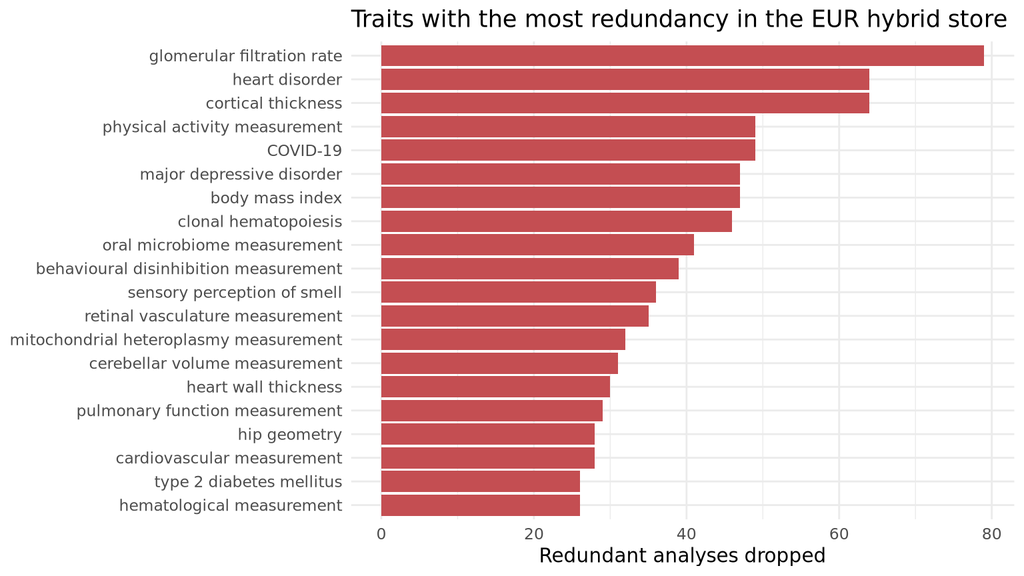

```r
top_redundant <- prio[recommendation == "redundant", .(dropped = .N),
                      by = MAPPED_TRAIT][order(-dropped)][1:20]
ggplot(top_redundant, aes(x = reorder(MAPPED_TRAIT, dropped), y = dropped)) +
  geom_col(fill = "#c44e52") +
  coord_flip() +
  labs(x = NULL, y = "Redundant analyses dropped",
       title = "Traits with the most redundancy in the EUR hybrid store") +
  theme_minimal(base_size = 11)
```

```r
DT::datatable(
  prio[cluster_size > 1,
       .(MAPPED_TRAIT, cluster_size, rank = cluster_rank, recommendation,
         power = power_metric, n_variants, hits = association_count,
         score = priority_score, pubmed_id = PUBMED.ID)],
  rownames = FALSE, filter = "top",
  options = list(pageLength = 15, scrollX = TRUE, order = list(list(1, "desc"))),
  caption = "EUR hybrid analyses in multi-analysis EFO clusters, ranked within trait.")
```

| MAPPED_TRAIT | cluster_size | rank | recommendation | power | n_variants | hits | score | pubmed_id |
| --- | --- | --- | --- | --- | --- | --- | --- | --- |
| glomerular filtration rate | 82 | 1 | keep | 1508659 | 12653804 | 878 | 0.9659 | 35710981 |
| glomerular filtration rate | 82 | 2 | keep | 1201930 | 13633840 | 483 | 0.9585 | 34272381 |
| glomerular filtration rate | 82 | 3 | keep | 1004040 | 13635145 | 178 | 0.9457 | 34272381 |
| glomerular filtration rate | 82 | 4 | redundant | 765348 | 8221591 | 307 | 0.903 | 31152163 |
| glomerular filtration rate | 82 | 5 | redundant | 567460 | 8834748 | 256 | 0.8994 | 31152163 |
| glomerular filtration rate | 82 | 6 | redundant | 406504 | 16984619 | 511 | 0.8902 | 39256582 |
| glomerular filtration rate | 82 | 7 | redundant | 406504 | 16984552 | 577 | 0.8878 | 39256582 |
| glomerular filtration rate | 82 | 8 | redundant | 406504 | 16984509 | 445 | 0.878 | 39256582 |
| glomerular filtration rate | 82 | 9 | redundant | 350514 | 26237160 | 147 | 0.8171 | 31015462 |
| glomerular filtration rate | 82 | 10 | redundant | 355731 | 9000000 | 349 | 0.7793 | 33462484 |

[output cut: 5080 more lines]